# circRNA_arabidopsis

```python
import pandas as pd
```

```python
from IPython import display
```

## Identification and characterization of circular RNAs in Arabidopsis

### Identification pipeline

note: This project began at the end of 2013. There was no available tools then. So Dr.Fu in my lab built this pipeline. I fixed the bugs in Fu's pipeline and added short cRNA identification pipeline. I also modified the pipeline of Memczak(2013) and Zhang(2014) to make them fit the pair-end strand-specific RNase+ data.

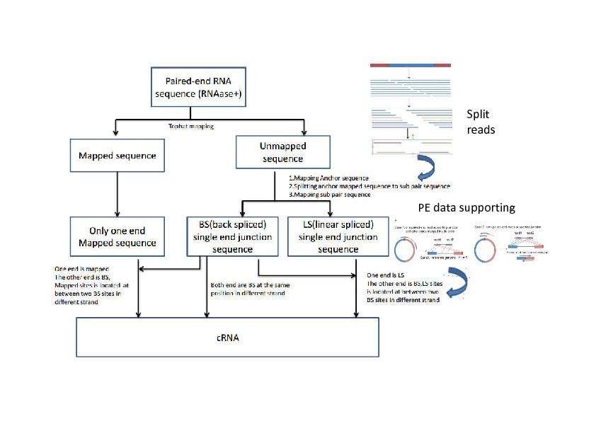

```python
display.Image("notebook_material/pipeline-0.jpeg")
```

**This pipeline could be used for Pair-end strand-specific RNase+ data. We could identify cRNA flanking GTAG or not.** In following analysis, we found that non-GTAG flanking cRNAs was the major type of cRNA in Arabidopsis. However, There is a problem for non-GTAG flanking cRNA identification: **Shift size**.The "shift problem" of circRNAs boundary were the major obstacle for the identification of non-GTAG circRNAs.(The shift was caused by the beginning of the back splice region was very similar to the end of the back splice region). 1-12 bp shifting was an common phenomenon in the non-GTAG circRNAs.

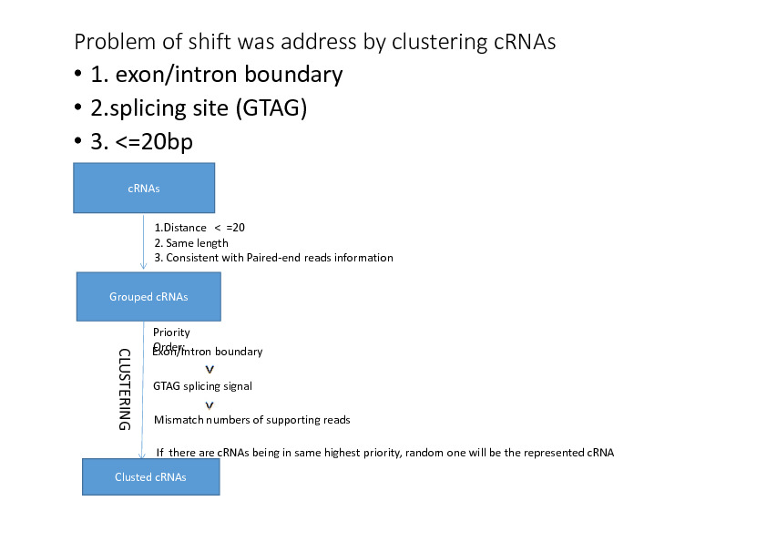

```python
display.Image("notebook_material/pipeline-2.jpeg")
```

Circular intronic RNA (lariat cRNA). cRNAs are detected in above pipeline located in intron (length > 100bp).Short cRNAs are detected in following pipeline. (length<=100bp)

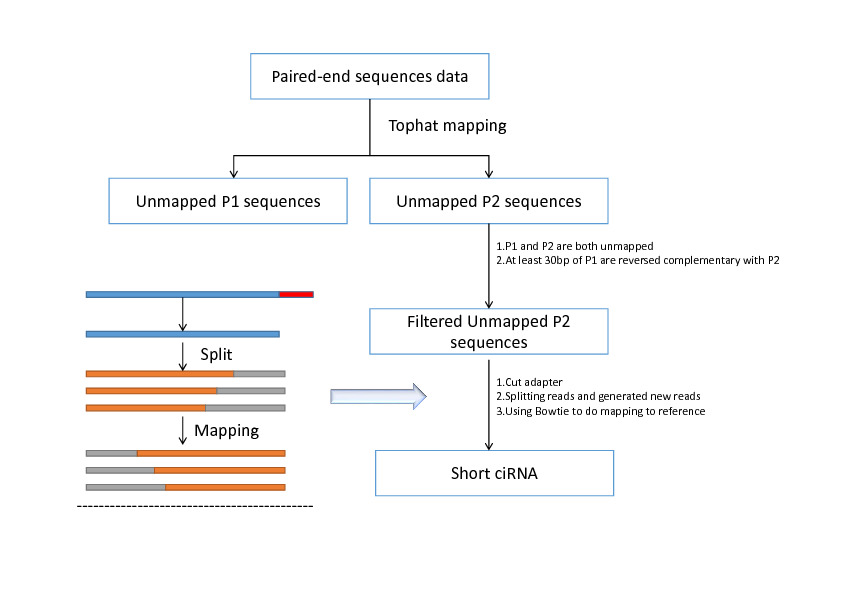

```python
display.Image("notebook_material/pipeline-3.jpeg")
```

```
qsub /psc/home/zhaocheng/My_project/Circular_RNA_project/bwa_mem.bash
qsub /psc/home/zhaocheng/My_project/Circular_RNA_project/bwa_mem.bash
```

CIRI pipeline

`qsub /psc/home/zhaocheng/My_project/Circular_RNA_project/cirBase.bash` modified Meczack pipeline for PE strand-specific date

`qsub /psc/home/zhaocheng/My_project/Circular_RNA_project/CIRCexployer.bash` modified Zhang pipeline for PE strand-specific date

```
qsub /psc/home/zhaocheng/My_project/Circular_RNA_project/tophat_htseq.bash
qsub /psc/home/zhaocheng/My_project/Circular_RNA_project/circRNAFinder3.bash
bash /psc/home/zhaocheng/My_project/Circular_RNA/Shift_size.bash
```

Dr.Fu pipeline: circRNA finder

## Results

### 1. Mapping Static

we used strand-specific pair-end RNAase+ RNA-seq for circRNAs. Samples were genereated from seedling, root, flower and leaf of arabidopsis

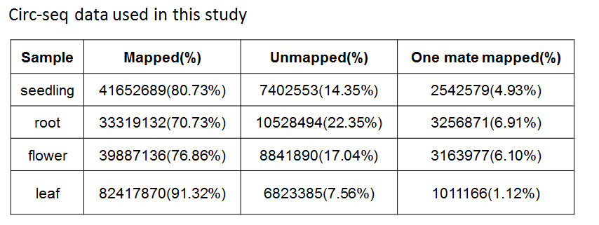

```python
display.Image("notebook_material/Data_information.png")
```

### 2. Method comparision

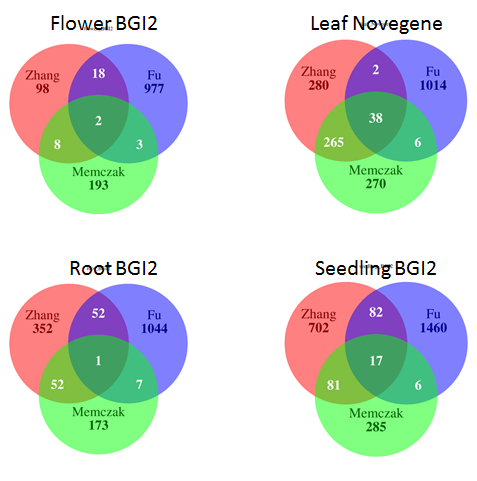

```python
display.Image("notebook_material/Method_comparisioon.png")
```

### 3. Number of circRNAs in different library

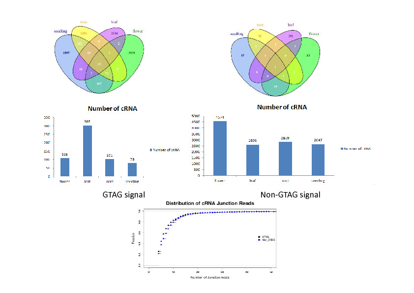

```python
display.Image("notebook_material/circRNA_result-0.jpeg")
```

### 4. Type of circRNAs( GTAG signlal circRNA and non-GTAG signal circRNA)

According to their location, classficated into different type.

`bash /psc/home/zhaocheng/My_project/Circular_RNA_properity/bin/cRNA_properity.bash`

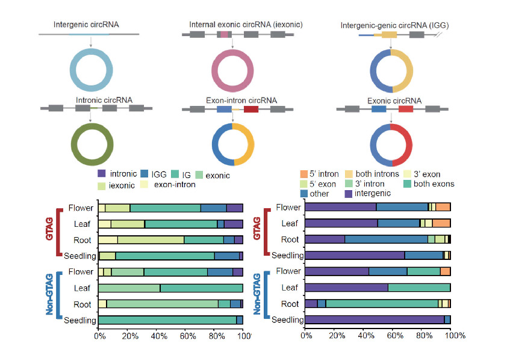

```python
display.Image("notebook_material/circRNA_result-1.jpeg")  ## Type of circRNAs and the proporation of circRNAs
```

### 5. Feature analysis of circRNAs flanking GTAG

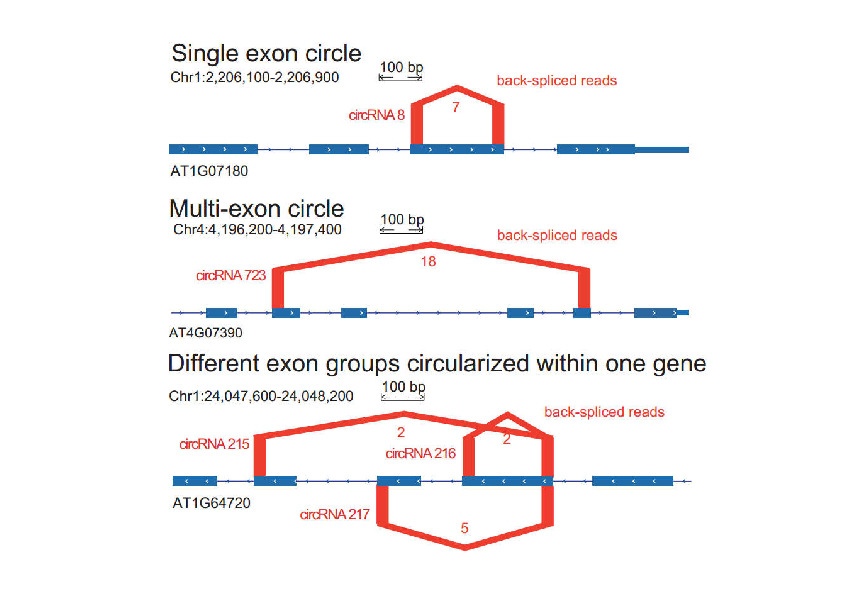

```python
display.Image("notebook_material/circRNA_result-2.jpeg")  ## Type of exonic circRNAs
```

Unliked reported in mouse and human, length of flanking introns of exonic circRNAs in Ath isn't longer than others. Exons in middle of genes tended to circulared. We also checked the reverse complementary matchs(RCM) of exonic circRNAs

```
bash /psc/home/zhaocheng/My_project/Circular_RNA/bin/Find_complentary.bash  ### We used intron sequence to blast against themselves
bash /psc/home/zhaocheng/My_project/WORK/bin/cRNA_FB_BG.bash
```

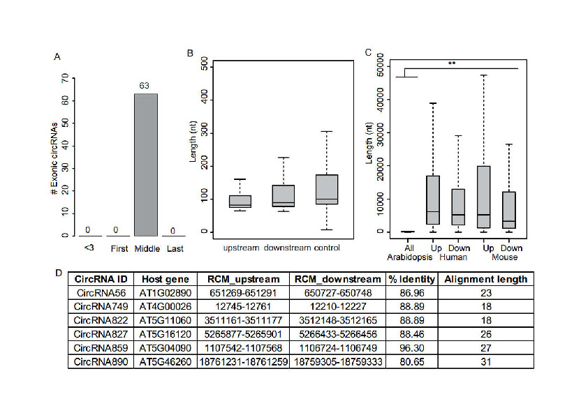

```python
display.Image("notebook_material/circRNA_result-3.jpeg")
##Unliked reported in mouse and human, length of flanking introns of exonic circRNAs in Ath isn't longer.
## Only 6 RCMs were identified around the exonic circRNAs
```

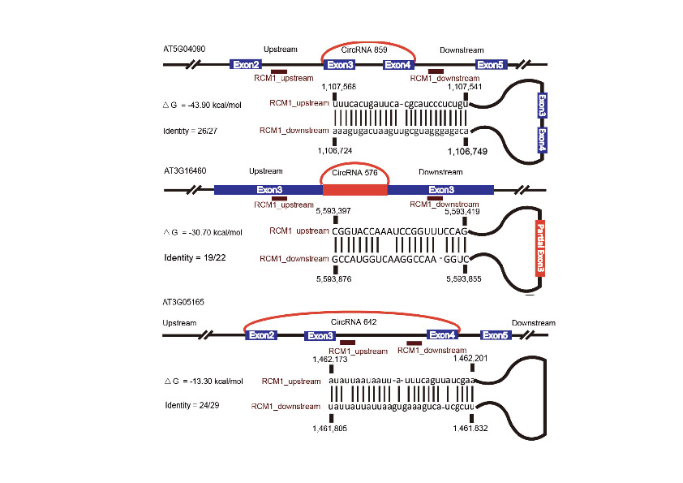

```python
display.Image("notebook_material/circRNA_result-4.jpeg")
#Three example of RCMs
```

`bash /psc/home/zhaocheng/My_project/WORK/bin/RCM/Free_Energy.bash ## RCM duplex`

`Rscript /psc/home/zhaocheng/My_project/WORK/src/RCM/RCM_DUPLEX.R`

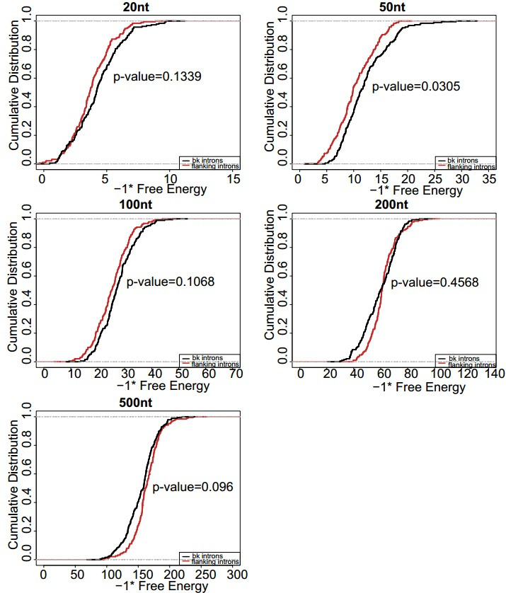

```python
display.Image("notebook_material/RCM_duplex.jpeg")
```

Conservation analysis of intron-exon boundary's sequence around exonic circRNAs.

Conservation scores was downloaded from [Conservation (phastCons) Analysis of Structure Hot Spots and Cold Spots and Their Flanking Region](http://gregorylab.bio.upenn.edu/ArabidopsisStructure/)

`bash /psc/home/zhaocheng/My_project/WORK/bin/Conservation.bash`

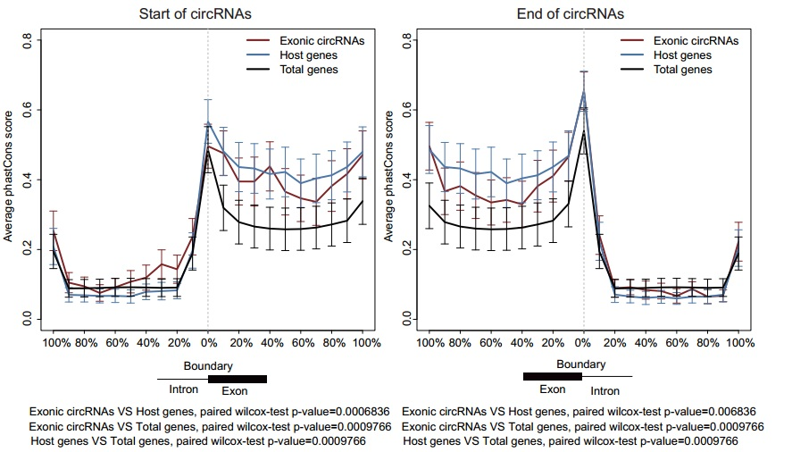

```python
display.Image("notebook_material/Conservation.jpeg")
```

**RCMs aren't the major reason for generation of circRNAs. And upstream intronic sequence have higher conservation score.**

### 6. Features analysis of non-GTAG signla circRNAs

circRNAs are generated in cluster at the neary region.

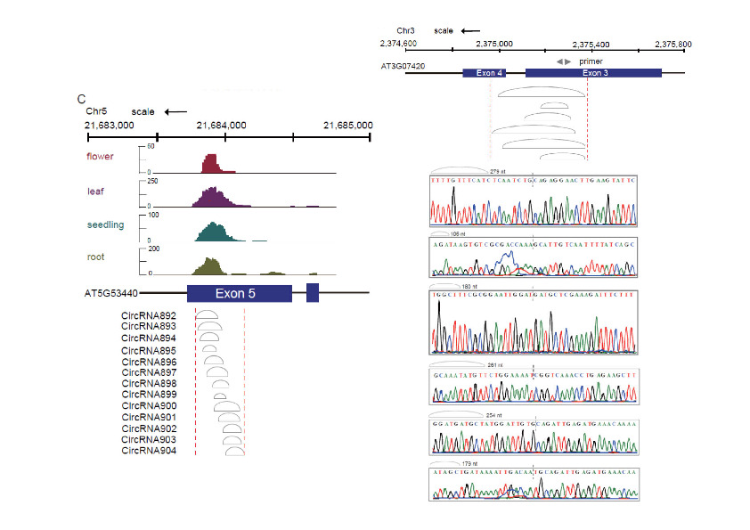

```python
display.Image("notebook_material/circRNA_result-5.jpeg") ##IGV AI
```

### 7. Feature analysis of host genes

7.1 **Are circRNAs correlated with their corresponding isoforms?**

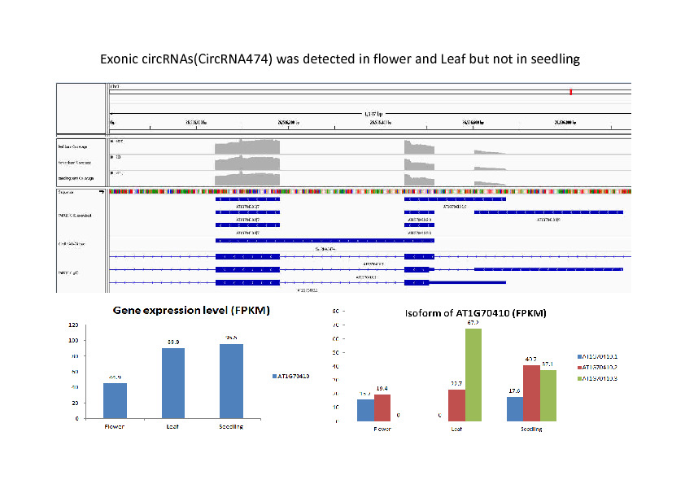

```python
display.Image("notebook_material/circRNA_result-6.jpeg")
```

7.2 **GO enrichment of tissue-specific circRNAs host genes**

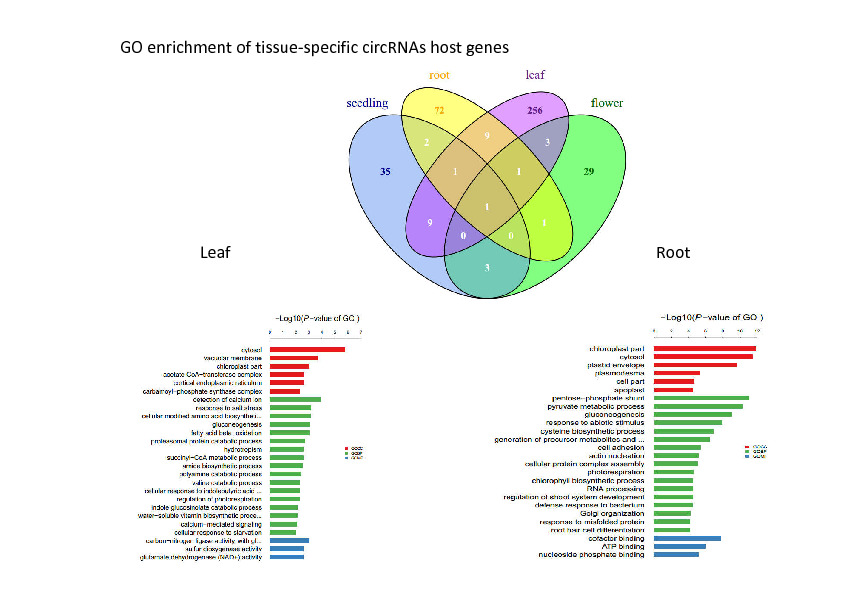

```python
display.Image("notebook_material/circRNA_result-7.jpeg")
```

**Note**: Collaborator: Gaozhan Zhao(experiment,tsinghua university), Yizhuang Zhou(bioinformatics,tsinghua university), Xing Fu(bioinformatics,SIBS) The results are still unpublished.I only put my part of results here.